# Variable selection ordered samples cellcycleR: (K=2)

Kushal K Dey

December 26, 2015

## Overview

Variable selection in topic models or in cellcyleR methods is an important matter of consideration. In this script, we shall consider an example simulation model for cells on the cell cycle or ordered samples (by time) and we apply variable selecion using sparse factor analysis. We use the *PMD()* function of the R package **PMA** for factor analysis and then use the factor loadings matrix to do the variable selection.

## Simulation design

```r
library(PMA)
library(cellcycleR)
library(wavethresh)
G <- 100;
num_cells <- 256;
amp_genes1 <- c(rep(8, G/4), rep(6, G/4), rep(0,G/4), rep(6,G/4));
phi_genes1 <- rep(c(2,5), each=G/2);
sigma_genes1 <- rchisq(G, 2);
cell_times_sim <- sort(sample(seq(0,2*pi, 2*pi/(num_cells-1)), num_cells, replace=FALSE));
cycle_data <- t(sim_sinusoidal_cycle(G, amp_genes1, phi_genes1, sigma_genes1, cell_times_sim));
```

By the way we have defined the set up, the genes from number $51$ to $75$ are unimportant as they have amplitudes $0$, meaning they only contribute to noise. Ideally, we would like to eliminate the non-informative genes before applying the topic model/cellcycleR on such a data for more accurate representation, removing unwanted noise and also faster implementation.

The sinusoidal patterns for two cases from the two groups of gene phases given as follows. Ideally these are how the two factors in a factor analysis model on this data would look like.

The cyclical pattern for $2$ nd gene

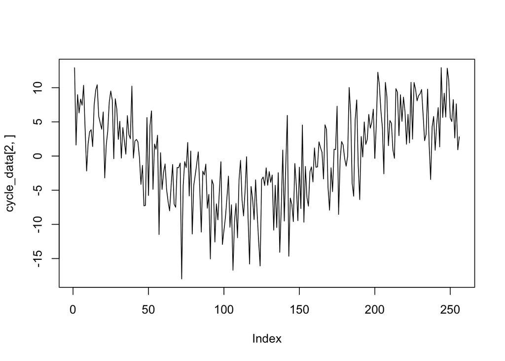

```r
plot(cycle_data[2,], type="l");
```

The pattern for $52$ nd gene (which has amplitude 0 and hence is all noise)

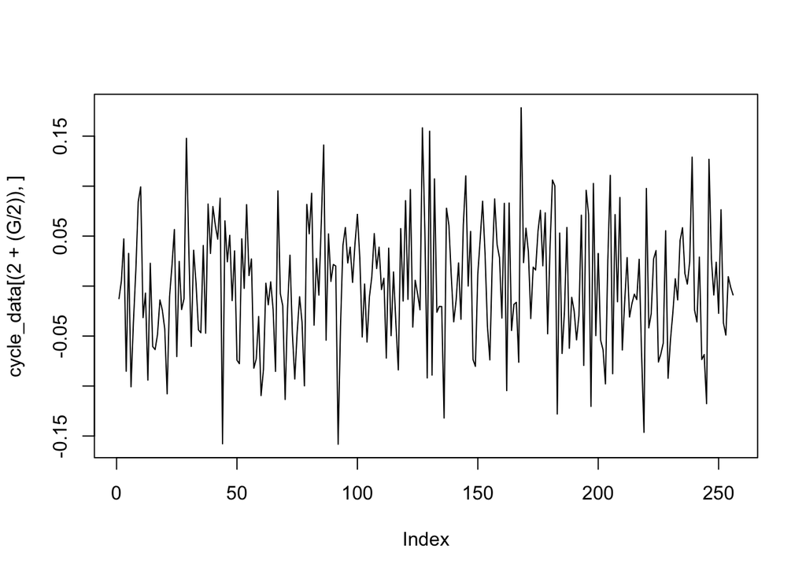

```r
plot(cycle_data[(2+(G/2)),], type="l")
```

## Wavelet transform of sinusoidal data matrix

We now first apply wavelet transform on the genes (rows) for the data matrix.

```r
wave_data <- t(apply(cycle_data, 1, function(x)
                                  {
                                      out <- wd(x, filter.number = 3, family = "DaubExPhase")
                                      return(out$D)
                                  }));
```

## Factor analysis on wavelet transformed data

We perform factor analysis on the genes.

```r
library(PMA)
pmd1 <- PMD(wave_data, type="standard", K=2, niter=50);
```

```
## 123456789101112131415161718192021222324252627
## 1234567891011121314151617181920212223242526272829
```

### Non shrunk factor loadings

We plot the barplot of the factor loadings, colors representing the two factors.

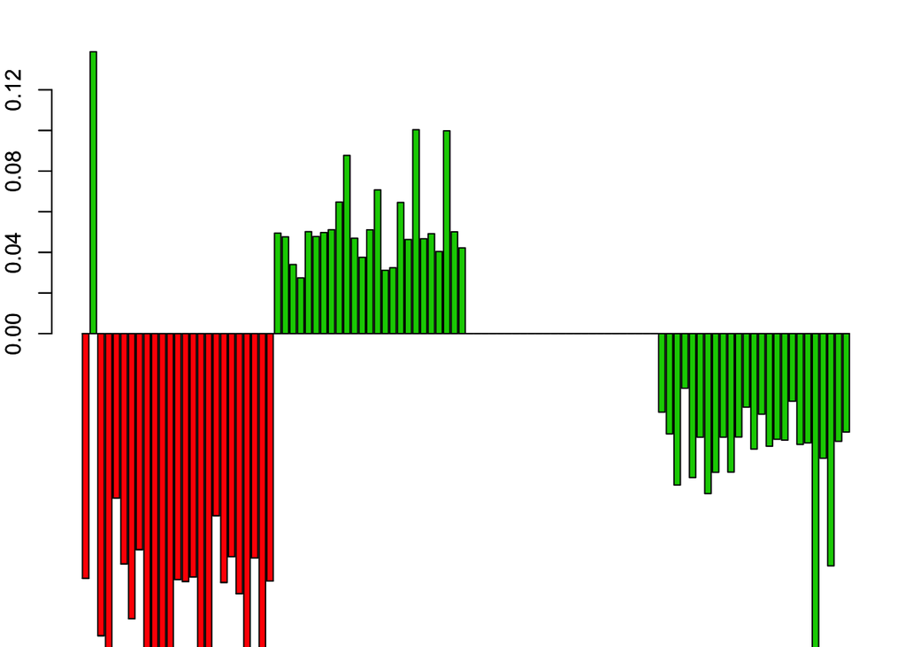

```r
pos_u <- apply(pmd1$u, c(1,2), function(x) return (max(x,0)))
neg_u <- apply(pmd1$u, c(1,2), function(x) return (min(x,0)))

par(mar=c(12,2,2,1))
barplot(t(pos_u), col=2:3)
barplot(t(neg_u), col=2:3, add=TRUE)
```

### Shrinking factor loadings

The sum of squared values of the columns of $u$ matrix from *PMD()* fit is 1 by definition. Check here

```r
apply(pmd1$u,2,function(x) return(sqrt(sum(x^2))))
```

```
## [1] 1 1
```

We assume that all the genes contribute equally to this variance or standard deviation of $1$ in the $u$ matrix and we assume the variance to be $1/G$, whhere $G$ is the total number of genes.

```r
library(ashr)
shrunk_u <- suppressWarnings(apply(pmd1$u, 2, function(x) return(ash(x,sqrt(1/length(x)))$PosteriorMean)));
```

```
## Due to absence of package REBayes, switching to EM algorithm
## Due to absence of package REBayes, switching to EM algorithm
```

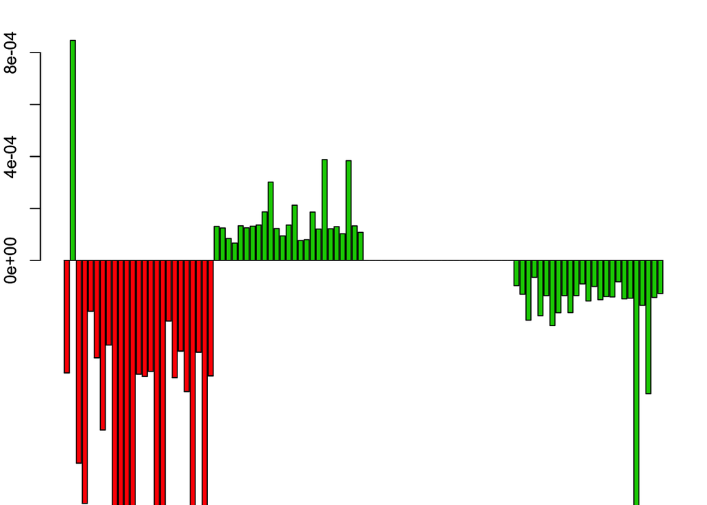

```r
pos_shrunk_u <- apply(shrunk_u, c(1,2), function(x) return (max(x,0)))
neg_shrunk_u <- apply(shrunk_u, c(1,2), function(x) return (min(x,0)))

par(mar=c(12,2,2,1))
barplot(t(pos_shrunk_u), col=2:3)
barplot(t(neg_shrunk_u), col=2:3, add=TRUE)
```

### Variable selection

The genes chosen after variable selection

```r
ss_loadings <- apply(shrunk_u,1,function(x) return(sqrt(sum(x^2))))
which(ss_loadings > 1e-06)
```

```
##  [1]   1   2   3   4   5   6   7   8   9  10  11  12  13  14  15  16  17
## [18]  18  19  20  21  22  23  24  25  26  27  28  29  30  31  32  33  34
## [35]  35  36  37  38  39  40  41  42  43  44  45  46  47  48  49  50  76
## [52]  77  78  79  80  81  82  83  84  85  86  87  88  89  90  91  92  93
## [69]  94  95  96  97  98  99 100
```

Note that for this threshold, we mostly get all the relevant genes. However for a stronger threshold, we do miss out on many genes, as is depicted next.

```r
which(ss_loadings > 1e-04)
```

```
##  [1]   1   2   3   4   5   6   7   8   9  10  11  12  13  14  15  16  17
## [18]  18  19  20  21  22  23  24  25  26  27  30  31  32  33  34  35  36
## [35]  38  39  42  43  44  45  46  47  48  49  50  77  78  80  81  82  83
## [52]  84  85  86  88  89  90  91  92  94  95  96  97  98  99 100
```

```r
which(ss_loadings > 1e-03)
```

```
## [1]  9 10 11 12 16 17 22 96
```

## Factor analysis without wavelet transform

We do the same analysis, but without the wavelet transform.

```r
library(PMA)
pmd1 <- PMD(cycle_data, type="standard", K=2, niter=50);
```

```
## 123456789101112131415161718192021222324252627282930313233343536373839404142
## 1234567891011121314151617181920212223242526272829303132333435363738394041424344454647484950
```

### Non shrunk loadings

We plot the barplot of the factor loadings, colors representing the two factors.

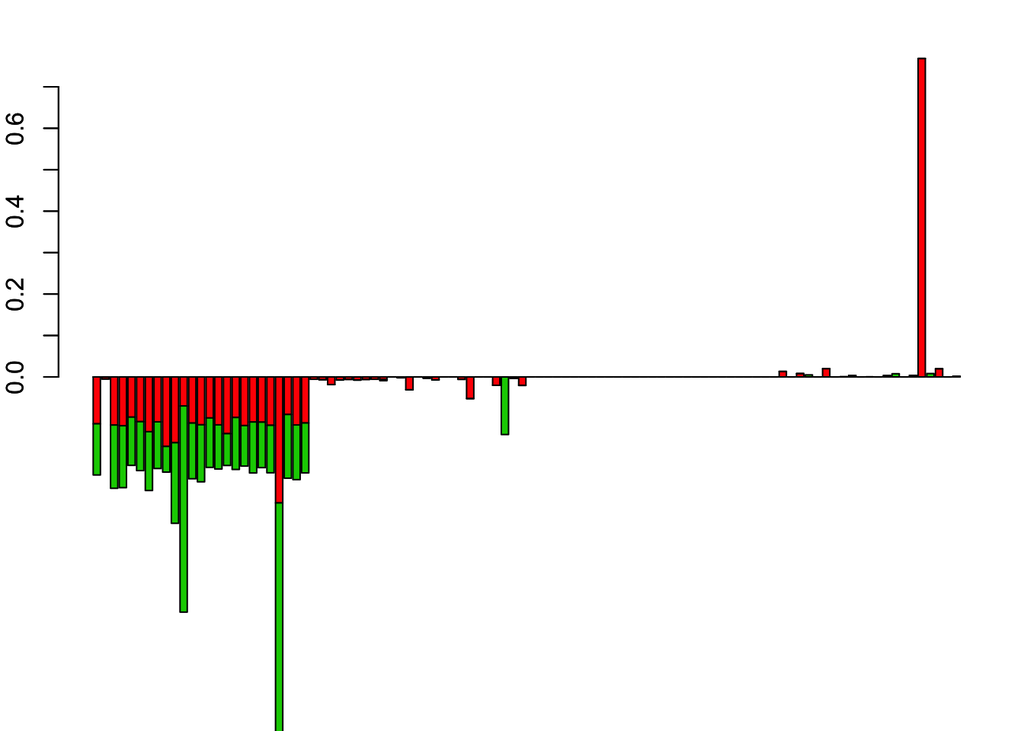

```r
pos_u <- apply(pmd1$u, c(1,2), function(x) return (max(x,0)))
neg_u <- apply(pmd1$u, c(1,2), function(x) return (min(x,0)))

par(mar=c(12,2,2,1))
barplot(t(pos_u), col=2:3)
barplot(t(neg_u), col=2:3, add=TRUE)
```

### Shrinking factor loadings

The sum of squared values of the columns of $u$ matrix from *PMD()* fit is 1 by definition. Check here

```r
apply(pmd1$u,2,function(x) return(sqrt(sum(x^2))))
```

```
## [1] 1 1
```

We assume that all the genes contribute equally to this variance or standard deviation of $1$ in the $u$ matrix and we assume the variance to be $1/G$, whhere $G$ is the total number of genes.

```r
library(ashr)
shrunk_u <- suppressWarnings(apply(pmd1$u, 2, function(x) return(ash(x,sqrt(1/length(x)))$PosteriorMean)));
```

```
## Due to absence of package REBayes, switching to EM algorithm
## Due to absence of package REBayes, switching to EM algorithm
```

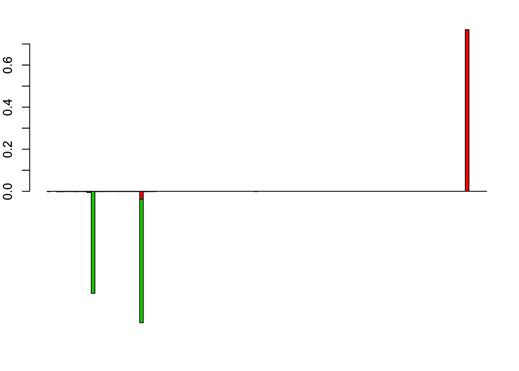

```r
pos_shrunk_u <- apply(shrunk_u, c(1,2), function(x) return (max(x,0)))
neg_shrunk_u <- apply(shrunk_u, c(1,2), function(x) return (min(x,0)))

par(mar=c(12,2,2,1))
barplot(t(pos_shrunk_u), col=2:3)
barplot(t(neg_shrunk_u), col=2:3, add=TRUE)
```

### Variable selection

The genes chosen after variable selection

```r
ss_loadings <- apply(shrunk_u,1,function(x) return(sqrt(sum(x^2))))
which(ss_loadings > 1e-06)
```

```
##  [1]   1   2   3   4   5   6   7   8   9  10  11  12  13  14  15  16  17
## [18]  18  19  20  21  22  23  24  25  26  27  28  29  30  31  32  33  34
## [35]  36  37  39  40  43  44  47  48  49  50  80  82  83  85  88  92  93
## [52]  95  96  97  98 100
```

Note that for this threshold, we mostly get all the relevant genes. However for a stronger threshold, we do miss out on many genes, as is depicted next.

```r
which(ss_loadings > 1e-04)
```

```
##  [1]  1  3  4  5  6  7  8  9 10 11 12 13 14 15 16 17 18 19 20 21 22 23 24
## [24] 25 48 96
```

```r
which(ss_loadings > 1e-03)
```

```
##  [1]  1  3  4  7 10 11 12 13 14 17 19 22 23 24 25 48 96
```

## Conclusion

The wavelet transformed factor analysis seemed more efficient than applying factor analysis straightaway to the original cycle data. So variable selection after factor analysis on wavelet transformed data is more recommended than directly applying it on the cyclic data.